# Coursework 3

# Exercise 1

Consider the below time-series.

1. Fit the time-series by using a linear regression model including only trend and periodic terms.

First I will read the CSV file and then make a new column to give a better time variable.

```r
library(fpp2)
```

```r
#Reading Data
data <- read.csv("D:\\Trintiy\\Junior Sophister\\Semester 1\\Forecasting\\Assignment\\half-hourly-system-demand-data-from-2-feb-2012-onwards-2016-06-14T05-29-36Z.csv")
head(data)
```

|  | date | period_ending_time | system_demand_actual | nem_demand_actual | nem_demand_forecast |
| --- | --- | --- | --- | --- | --- |
| 1 | 2012-02-06 | 00:30 | 4526.68 | na | na |
| 2 | 2012-02-06 | 01:00 | 4436.09 | na | na |
| 3 | 2012-02-06 | 01:30 | 4361.24 | na | na |
| 4 | 2012-02-06 | 02:00 | 4295.23 | na | na |
| 5 | 2012-02-06 | 02:30 | 4233.17 | na | na |
| 6 | 2012-02-06 | 03:00 | 4191.87 | na | na |

```r
#Making a time column to make the data easier to use
data$time = as.POSIXlt(paste(data$date, data$period_ending_time),
                       format="%Y-%m-%d %H:%M")
data = data[order(data$time),]
```

Now I will fit a trend to the data, after looking at the residuals we can decide to add seasonality.

```r
library(fpp2)
library(lubridate)
```

```r
y = data$system_demand_actual # value we aim to forecast
freq = 1/(2*24*365.25)
t = seq(freq, length(y)*freq,by=freq)
#for making the plots less dense
plot(t,y,type='l')


#transform y into a column vector
Y <- as.matrix(y)
#transform time into a column vector
X <- as.matrix(t)
# Add intercept column to X
ones <- rep(1, length(t))
X <- cbind(ones, X)

betas <- solve(t(X) %*% X) %*% t(X) %*% Y
betas
```

[output not shown]

```
##          [,1]
## ones 5295.979
##       122.634
```

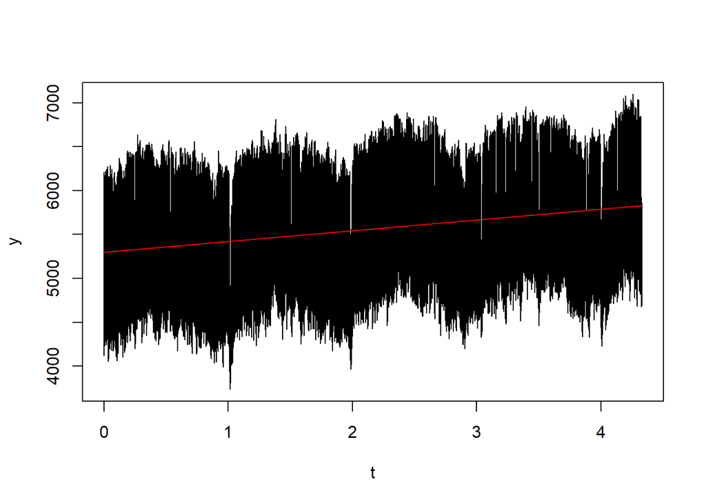

```r
plot(t,y,type='l')
ypred <- betas[2]*t+betas[1]
lines(t,ypred,col='red')
```

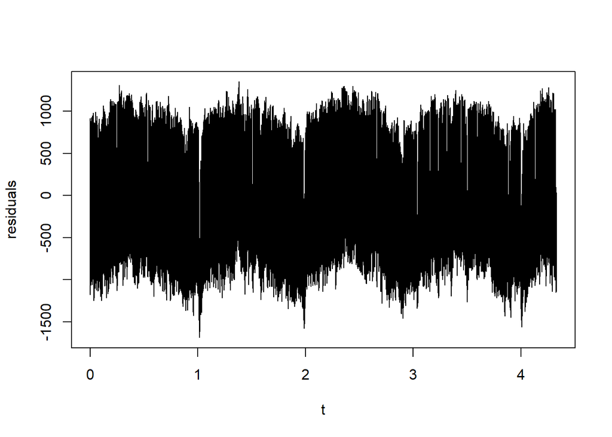

```r
residuals = y-ypred
plot(t,residuals,type='l')
```

```r
#hourly
X <- as.matrix(t)
X <- cbind(ones, X)
m1=2*24*freq
fourier1 = cbind(sin(2*pi*t/m1),cos(2*pi*t/m1),
      sin(2*pi*t*2/m1),cos(2*pi*t*2/m1),
      sin(2*pi*t*3/m1),cos(2*pi*t*3/m1))
# Add intercept column to X
X <- cbind(X,fourier1)
round(X[1:3,],6)
```

```
##      ones
## [1,]    1 0.000057 0.130526 0.991445 0.258819 0.965926 0.382683 0.923880
## [2,]    1 0.000114 0.258819 0.965926 0.500000 0.866025 0.707107 0.707107
## [3,]    1 0.000171 0.382683 0.923880 0.707107 0.707107 0.923880 0.382683
```

```r
lmmodel <- lm(Y~X-1)
lmmodel
```

```
##
## Call:
## lm(formula = Y ~ X - 1)
##
## Coefficients:
##    Xones         X         X         X         X         X         X         X
## 5296.103   122.577  -171.866  -686.027  -166.049  -106.666    -6.662    15.427
```

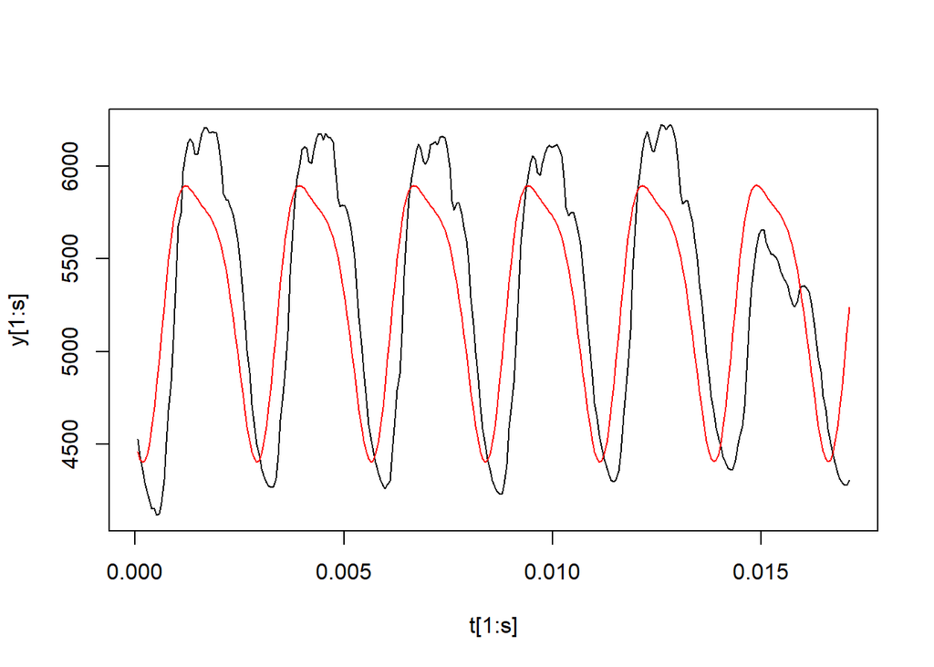

```r
s=300
plot(t[1:s],y[1:s],type='l')
ypred <- X%*%lmmodel$coefficients
lines(t[1:s],ypred[1:s],col='red')
```

```r
#Weekly

m2=2*24*7*freq
fourier2 = cbind(sin(2*pi*t/m2),cos(2*pi*t/m2),
      sin(2*pi*t*2/m2),cos(2*pi*t*2/m2),
      sin(2*pi*t*3/m2),cos(2*pi*t*3/m2),
      sin(2*pi*t*4/m2),cos(2*pi*t*4/m2)
      )
# Add intercept column to X
X <- cbind(X,fourier2)
round(X[1:3,],2)
```

```
##      ones
## [1,]    1 0 0.13 0.99 0.26 0.97 0.38 0.92 0.02 1 0.04 1.00 0.06 1.00 0.07 1.00
## [2,]    1 0 0.26 0.97 0.50 0.87 0.71 0.71 0.04 1 0.07 1.00 0.11 0.99 0.15 0.99
## [3,]    1 0 0.38 0.92 0.71 0.71 0.92 0.38 0.06 1 0.11 0.99 0.17 0.99 0.22 0.97
```

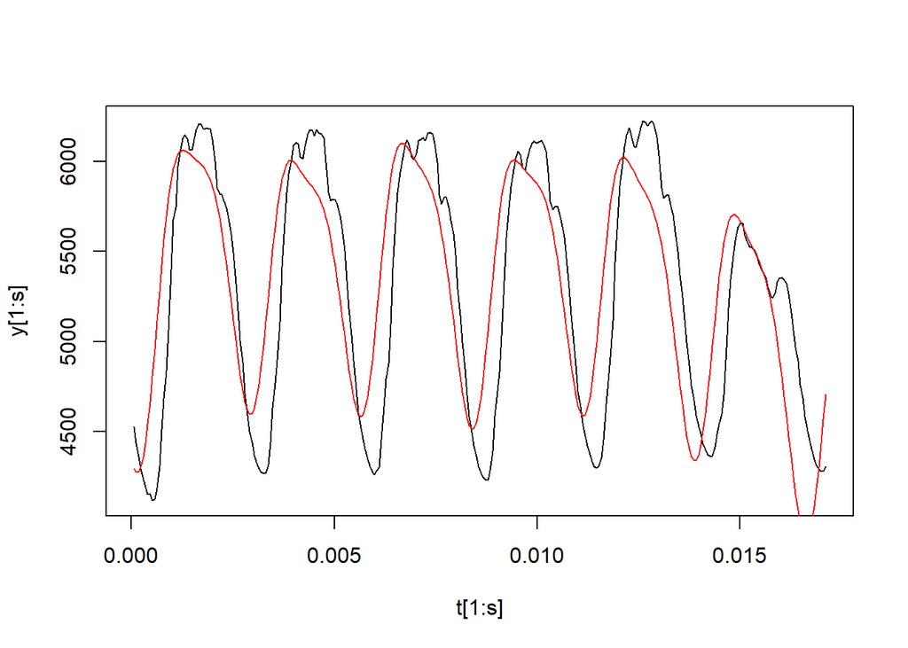

```r
lmmodel <- lm(Y~X-1)

s=300
plot(t[1:s],y[1:s],type='l')
ypred <- X%*%lmmodel$coefficients
lines(t[1:s],ypred[1:s],col='red')
```

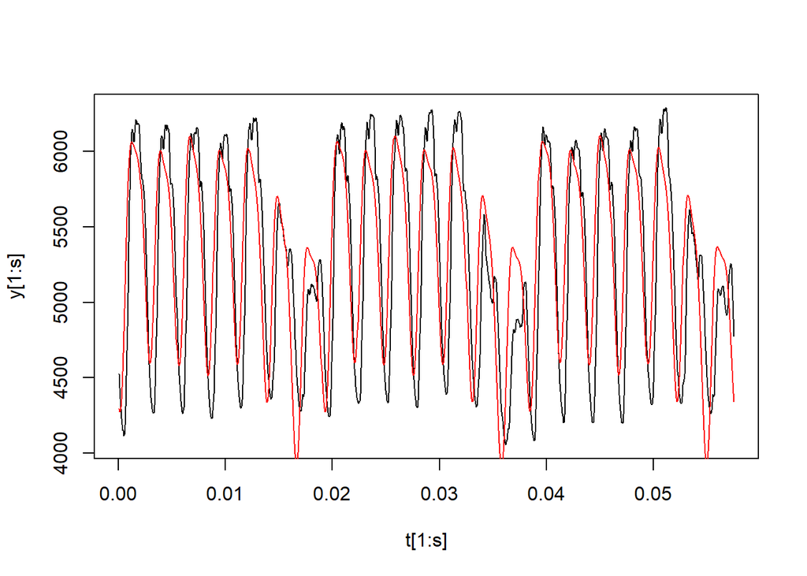

```r
s=2*24*7*3
plot(t[1:s],y[1:s],type='l')
ypred <- X%*%lmmodel$coefficients
lines(t[1:s],ypred[1:s],col='red')
```

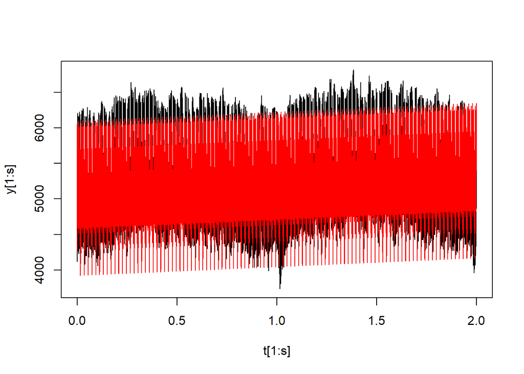

```r
s=1/freq*2
plot(t[1:s],y[1:s],type='l')
ypred <- X%*%lmmodel$coefficients
lines(t[1:s],ypred[1:s],col='red')
```

```r
#Yearly
m3=1
fourier3 = cbind(sin(2*pi*t/m3),cos(2*pi*t/m3),
      sin(2*pi*t*2/m3),cos(2*pi*t*2/m3),
      sin(2*pi*t*3/m3),cos(2*pi*t*3/m3))
# Add intercept column to X
X <- cbind(X,fourier3)
round(X[1:3,],2)
```

```
##      ones
## [1,]    1 0 0.13 0.99 0.26 0.97 0.38 0.92 0.02 1 0.04 1.00 0.06 1.00 0.07 1.00
## [2,]    1 0 0.26 0.97 0.50 0.87 0.71 0.71 0.04 1 0.07 1.00 0.11 0.99 0.15 0.99
## [3,]    1 0 0.38 0.92 0.71 0.71 0.92 0.38 0.06 1 0.11 0.99 0.17 0.99 0.22 0.97
##
## [1,] 0 1 0 1 0 1
## [2,] 0 1 0 1 0 1
## [3,] 0 1 0 1 0 1
```

```r
# Implement closed-form solution
lmmodel <- lm(Y~X-1)
lmmodel
```

```
##
## Call:
## lm(formula = Y ~ X - 1)
##
## Coefficients:
##    Xones         X         X         X         X         X         X         X
## 5274.987   131.535  -171.791  -686.031  -166.012  -106.671    -6.637    15.422
##        X         X         X         X         X         X         X         X
##  199.927  -181.038   173.846   -14.006    76.908    28.968    60.304   -15.756
##        X         X         X         X         X         X
##   90.533  -153.312    38.198   -38.963    20.672     8.366
```

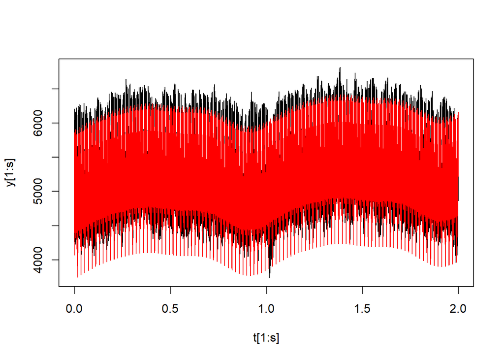

```r
s=2/freq
plot(t[1:s],y[1:s],type='l')
ypred <- X%*%lmmodel$coefficients
lines(t[1:s],ypred[1:s],col='red')
```

We can see that this model fits the data better than the trend alone.

2. Use the AIC criterion (R command `AIC(model)’) to find the optimal number of Fourier components for each periodic term. Use an exhaustive search by trying all the values $k \in [6,10]$ for each component. For instance, if you consider two periodic terms, then you have to try 25 possible combinations $K_1=6,K_2=6$, $K_1=6,K_2=7$, …, $K_1=6,K_2=10$,…,$K_1=10,K_2=6$, …$K_1=10,K_2=10$ (suggestion: use for loops).

```r
library(fpp2)
library(lubridate)
y = data$system_demand_actual # value we aim to forecast
freq = 1/(2*24*365.25)
t = seq(freq, length(y)*freq,by=freq)

#transform y into a column vector
Y <- as.matrix(y)
#transform time into a column vector
X <- as.matrix(t)
# Add intercept column to X
ones <- rep(1, length(t))
X <- cbind(ones, X)

lowest_AIC <- 0
lowest_x <- 0
lowest_k <- 0
lowest_w <- 0

for (x in 6:10) {
  #hourly
  X <- as.matrix(t)
  X <- cbind(ones, X)
  m1=24*freq
  if (x>=7) {x7 <- 7;x71<- 1} else {x7 <- 0;x71<- 0}
  if (x>=8) {x8 <- 8;x81<- 1} else {x8 <- 0;x81<- 0}
  if (x>=9) {x9 <- 9;x91<- 1} else {x9 <- 0;x91<- 0}
  if (x==10) {x10 <- 10;x101<- 1} else {x10 <- 0;x101<- 0}
  fourier1 = cbind(sin(2*pi*t*1/m1),cos(2*pi*t*1/m1), sin(2*pi*t*2/m1),cos(2*pi*t*2/m1), sin(2*pi*t*3/m1),cos(2*pi*t*3/m1)
                   , sin(2*pi*t*4/m1),cos(2*pi*t*4/m1), sin(2*pi*t*5/m1),cos(2*pi*t*5/m1), sin(2*pi*t*6/m1),cos(2*pi*t*6/m1)
                   , x71*sin(2*pi*t*x7/m1),x71*cos(2*pi*t*x7/m1), x81*sin(2*pi*t*x8/m1),x81*cos(2*pi*t*x8/m1),
                   x91*sin(2*pi*t*x9/m1),x91*cos(2*pi*t*x9/m1), x101*sin(2*pi*t*x10/m1),x101*cos(2*pi*t*x10/m1))
  fourier1<-fourier1[, colSums(fourier1 != 0) > 0]

  for (k in 10:10) {
    #Weekly
    #This should be 6:10, but that takes too long so I excluded it

    m2=24*7*freq
    if (k>=7) {k7 <- 7;k71<- 1} else {k7 <- 0;k71<- 0}
    if (k>=8) {k8 <- 8;k81<- 1} else {k8 <- 0;k81<- 0}
    if (k>=9) {k9 <- 9;k91<- 1} else {k9 <- 0;k91<- 0}
    if (k==10) {k10 <- 10;k101<- 1} else {k10 <- 0;k101<- 0}
    fourier2 = cbind(sin(2*pi*t*1/m2),cos(2*pi*t*1/m2), sin(2*pi*t*2/m2),cos(2*pi*t*2/m2), sin(2*pi*t*3/m2),cos(2*pi*t*3/m2)
                    , sin(2*pi*t*4/m2),cos(2*pi*t*4/m2), sin(2*pi*t*5/m2),cos(2*pi*t*5/m2), sin(2*pi*t*6/m2),cos(2*pi*t*6/m2)
                    , k71*sin(2*pi*t*k7/m2),k71*cos(2*pi*t*k7/m2), k81*sin(2*pi*t*k8/m2),k81*cos(2*pi*t*k8/m2),
                    k91*sin(2*pi*t*k9/m2),k91*cos(2*pi*t*k9/m2), k101*sin(2*pi*t*k10/m2),k101*cos(2*pi*t*k10/m2))
    fourier2<-fourier2[, colSums(fourier1 != 0) > 0]
    # Add intercept column to X
    X <- cbind(X,fourier2)
    round(X[1:3,],2)

    lmmodel <- lm(Y~X-1)
    lmmodel

    for (w in 10:10) {
      #Yearly
      #This should be 6:10, but that takes too long so I excluded it
      m3=1
      if (w>=7) {w7 <- 7;w71<- 1} else {w7 <- 0;w71<- 0}
      if (w>=8) {w8 <- 8;w81<- 1} else {w8 <- 0;w81<- 0}
      if (w>=9) {w9 <- 9;w91<- 1} else {w9 <- 0;w91<- 0}
      if (w==10) {w10 <- 10;w101<- 1} else {w10 <- 0;w101<- 0}
      fourier3 = cbind(sin(2*pi*t*1/m3),cos(2*pi*t*1/m3), sin(2*pi*t*2/m3),cos(2*pi*t*2/m3), sin(2*pi*t*3/m3),cos(2*pi*t*3/m3)
                      , sin(2*pi*t*4/m3),cos(2*pi*t*4/m3), sin(2*pi*t*5/m3),cos(2*pi*t*5/m3), sin(2*pi*t*6/m3),cos(2*pi*t*6/m3)
                      , w71*sin(2*pi*t*w7/m3),w71*cos(2*pi*t*w7/m3), w81*sin(2*pi*t*w8/m3),w81*cos(2*pi*t*w8/m3),
                      w91*sin(2*pi*t*w9/m3),w91*cos(2*pi*t*w9/m3), w101*sin(2*pi*t*w10/m3),w101*cos(2*pi*t*w10/m3))
      fourier3<-fourier3[, colSums(fourier1 != 0) > 0]
      # Add intercept column to X
      X <- cbind(X,fourier3)
      round(X[1:3,],2)

      # Implement closed-form solution
      lmmodel <- lm(Y~X-1)
      lmmodel

      #Updating the best AIC and ks
      current_AIC <- AIC(lmmodel)
      if (lowest_AIC==0) {lowest_AIC <- current_AIC;lowest_x <- x;lowest_k <- k;lowest_w <- w}
      else if (current_AIC<lowest_AIC){lowest_AIC <- current_AIC;lowest_x <- x;lowest_k <- k;
      lowest_w <- w} else{}
    }
  }
}
```

3. For the optimal model (best AIC), compute the one-week ahead forecast and plot it.

```r
data <- read.csv("D:\\Trintiy\\Junior Sophister\\Semester 1\\Forecasting\\Assignment\\half-hourly-system-demand-data-from-2-feb-2012-onwards-2016-06-14T05-29-36Z.csv")
data$time = as.POSIXlt(paste(data$date, data$period_ending_time),
                       format="%Y-%m-%d %H:%M")
data = data[order(data$time),]

y = data$system_demand_actual # value we aim to forecast
freq = 1/(2*24*365.25)
t = seq(freq, length(y)*freq,by=freq)


#transform y into a column vector
Y <- as.matrix(y)
#transform time into a column vector
X <- as.matrix(t)
# Add intercept column to X
ones <- rep(1, length(t))
X <- cbind(ones, X)


#hourly
X <- as.matrix(t)
X <- cbind(ones, X)
m1=2*24*freq
fourier1 = cbind(sin(2*pi*t/m1),cos(2*pi*t/m1),
      sin(2*pi*t*2/m1),cos(2*pi*t*2/m1),
      sin(2*pi*t*3/m1),cos(2*pi*t*3/m1),
      sin(2*pi*t*4/m1),cos(2*pi*t*4/m1),
      sin(2*pi*t*5/m1),cos(2*pi*t*5/m1),
      sin(2*pi*t*6/m1),cos(2*pi*t*6/m1))
# Add intercept column to X
X <- cbind(X,fourier1)
round(X[1:6,],6)
```

```
##      ones
## [1,]    1 0.000057 0.130526 0.991445 0.258819 0.965926 0.382683  0.923880
## [2,]    1 0.000114 0.258819 0.965926 0.500000 0.866025 0.707107  0.707107
## [3,]    1 0.000171 0.382683 0.923880 0.707107 0.707107 0.923880  0.382683
## [4,]    1 0.000228 0.500000 0.866025 0.866025 0.500000 1.000000  0.000000
## [5,]    1 0.000285 0.608761 0.793353 0.965926 0.258819 0.923880 -0.382683
## [6,]    1 0.000342 0.707107 0.707107 1.000000 0.000000 0.707107 -0.707107
##
## [1,] 0.500000  0.866025  0.608761  0.793353  0.707107  0.707107
## [2,] 0.866025  0.500000  0.965926  0.258819  1.000000  0.000000
## [3,] 1.000000  0.000000  0.923880 -0.382683  0.707107 -0.707107
## [4,] 0.866025 -0.500000  0.500000 -0.866025  0.000000 -1.000000
## [5,] 0.500000 -0.866025 -0.130526 -0.991445 -0.707107 -0.707107
## [6,] 0.000000 -1.000000 -0.707107 -0.707107 -1.000000  0.000000
```

```r
lmmodel <- lm(Y~X-1)


#Weekly

m2=2*24*7*freq
fourier2 = cbind(sin(2*pi*t/m2),cos(2*pi*t/m2),
      sin(2*pi*t*2/m2),cos(2*pi*t*2/m2),
      sin(2*pi*t*3/m2),cos(2*pi*t*3/m2),
      sin(2*pi*t*4/m2),cos(2*pi*t*4/m2),
      sin(2*pi*t*5/m2),cos(2*pi*t*5/m2),
      sin(2*pi*t*6/m2),cos(2*pi*t*6/m2),
      sin(2*pi*t*7/m2),cos(2*pi*t*7/m2),
      sin(2*pi*t*8/m2),cos(2*pi*t*8/m2),
      sin(2*pi*t*9/m2),cos(2*pi*t*9/m2),
      sin(2*pi*t*10/m2),cos(2*pi*t*10/m2))
# Add intercept column to X
X <- cbind(X,fourier2)
round(X[1:3,],2)
```

```
##      ones
## [1,]    1 0 0.13 0.99 0.26 0.97 0.38 0.92 0.50 0.87 0.61  0.79 0.71  0.71 0.02
## [2,]    1 0 0.26 0.97 0.50 0.87 0.71 0.71 0.87 0.50 0.97  0.26 1.00  0.00 0.04
## [3,]    1 0 0.38 0.92 0.71 0.71 0.92 0.38 1.00 0.00 0.92 -0.38 0.71 -0.71 0.06
##
## [1,] 1 0.04 1.00 0.06 1.00 0.07 1.00 0.09 1.00 0.11 0.99 0.13 0.99 0.15 0.99
## [2,] 1 0.07 1.00 0.11 0.99 0.15 0.99 0.19 0.98 0.22 0.97 0.26 0.97 0.29 0.96
## [3,] 1 0.11 0.99 0.17 0.99 0.22 0.97 0.28 0.96 0.33 0.94 0.38 0.92 0.43 0.90
##
## [1,] 0.17 0.99 0.19 0.98
## [2,] 0.33 0.94 0.37 0.93
## [3,] 0.48 0.88 0.53 0.85
```

```r
lmmodel <- lm(Y~X-1)

#Yearly
m3=1
fourier3 = cbind(sin(2*pi*t/m3),cos(2*pi*t/m3),
      sin(2*pi*t*2/m3),cos(2*pi*t*2/m3),
      sin(2*pi*t*3/m3),cos(2*pi*t*3/m3),
      sin(2*pi*t*4/m3),cos(2*pi*t*4/m3),
      sin(2*pi*t*5/m3),cos(2*pi*t*5/m3),
      sin(2*pi*t*6/m3),cos(2*pi*t*6/m3),
      sin(2*pi*t*7/m3),cos(2*pi*t*7/m3),
      sin(2*pi*t*8/m3),cos(2*pi*t*8/m3),
      sin(2*pi*t*9/m3),cos(2*pi*t*9/m3),
      sin(2*pi*t*10/m3),cos(2*pi*t*10/m3))
# Add intercept column to X
X <- cbind(X,fourier3)
round(X[1:3,],2)
```

```
##      ones
## [1,]    1 0 0.13 0.99 0.26 0.97 0.38 0.92 0.50 0.87 0.61  0.79 0.71  0.71 0.02
## [2,]    1 0 0.26 0.97 0.50 0.87 0.71 0.71 0.87 0.50 0.97  0.26 1.00  0.00 0.04
## [3,]    1 0 0.38 0.92 0.71 0.71 0.92 0.38 1.00 0.00 0.92 -0.38 0.71 -0.71 0.06
##
## [1,] 1 0.04 1.00 0.06 1.00 0.07 1.00 0.09 1.00 0.11 0.99 0.13 0.99 0.15 0.99
## [2,] 1 0.07 1.00 0.11 0.99 0.15 0.99 0.19 0.98 0.22 0.97 0.26 0.97 0.29 0.96
## [3,] 1 0.11 0.99 0.17 0.99 0.22 0.97 0.28 0.96 0.33 0.94 0.38 0.92 0.43 0.90
##
## [1,] 0.17 0.99 0.19 0.98 0 1 0 1 0 1 0 1 0.00 1 0.00 1 0.00 1 0.00 1 0.00 1
## [2,] 0.33 0.94 0.37 0.93 0 1 0 1 0 1 0 1 0.00 1 0.00 1 0.01 1 0.01 1 0.01 1
## [3,] 0.48 0.88 0.53 0.85 0 1 0 1 0 1 0 1 0.01 1 0.01 1 0.01 1 0.01 1 0.01 1
##
## [1,] 0.00 1
## [2,] 0.01 1
## [3,] 0.01 1
```

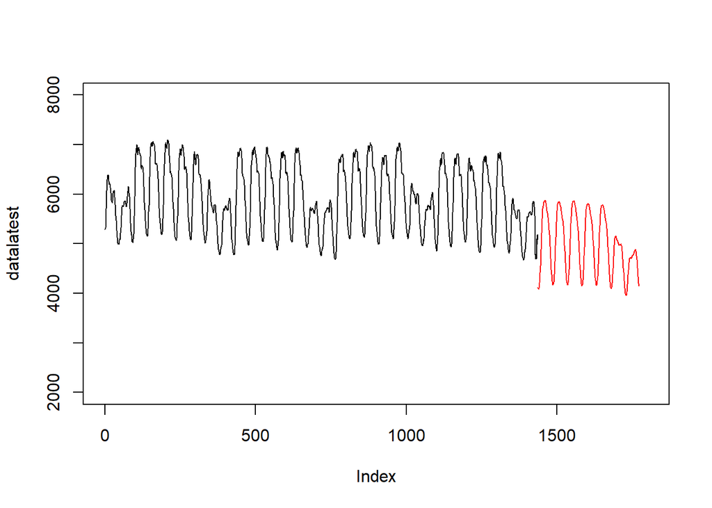

```r
# Implement closed-form solution
lmmodel <- lm(Y~X-1)

forecast <- matrix(head(predict(lmmodel), n=(2*24*7)))

datalatest <- data[74500:75936,]
t <- ((75937-74500):((75936-74500)+(2*24*7)))

datalatest <- matrix(c(datalatest$system_demand_actual))
plot(datalatest,type = 'l', xlim = c(0,1800), ylim = c(2000,8000))
lines(t, forecast,col='red')
```

# Exercise 2

Consider the below code.

1. Can you explain how the below regression model works?
2. What happens if you set lag = 300 or lag =336? Which value is better? Why?
3. How can you compute the forecast one-week ahead using the below model?
4. Can you explain how the below regression model works?

In this regression model, it uses the lag of the data to model it. It goes to the 336th data point and uses the previous 336 values to predict the value. We are using as predictors their lagged values. Explaination of code below.

```r
#Reading in the csv file
data <- read.csv("D:\\Trintiy\\Junior Sophister\\Semester 1\\Forecasting\\Assignment\\half-hourly-system-demand-data-from-2-feb-2012-onwards-2016-06-14T05-29-36Z.csv")
#Isolating data to forecast
y = data$system_demand_actual
#Setting the lag wanted
lag=336
#Creating a matrix where each row is the current value and then all 336 previous values
X = do.call("rbind", lapply(list(y), function(x) embed(x, lag+1)))
#Making a new array from the first column, which is the current values & Removing this column from the X matrix
Y = X[,1]; X = X[,-1]
#Creating a model to predict Y from X. -1 Removes the intercept.
lmmodel = lm(Y~X-1)
```

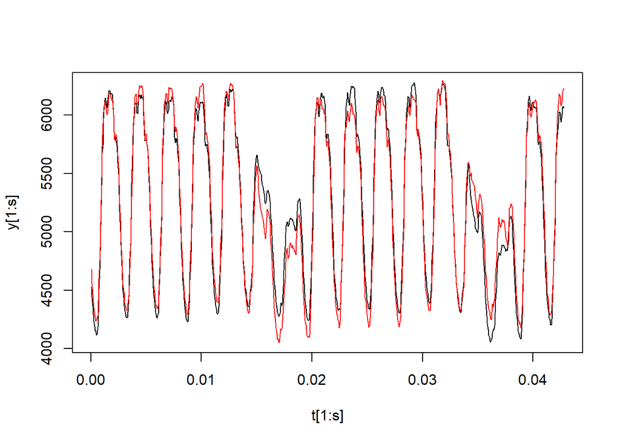

```r
#This code is just to plot the model vs the series
freq = 1/(2*24*365.25)
t = seq(freq, length(y)*freq,by=freq)
s=750
plot(t[1:s],y[1:s],type='l')
ypred <- X%*%lmmodel$coefficients
lines(t[1:s],ypred[1:s],col='red')
```

2. What happens if you set lag = 300 or lag =336? Which value is better? Why?

```r
data <- read.csv("D:\\Trintiy\\Junior Sophister\\Semester 1\\Forecasting\\Assignment\\half-hourly-system-demand-data-from-2-feb-2012-onwards-2016-06-14T05-29-36Z.csv")
y = data$system_demand_actual
lag=300
X = do.call("rbind", lapply(list(y), function(x) embed(x, lag+1)))
Y = X[,1]; X = X[,-1]
lmmodel = lm(Y~X-1)
```

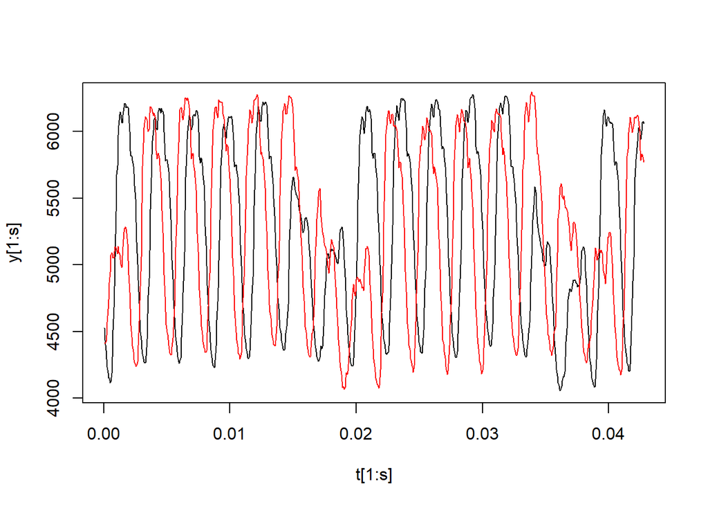

```r
freq = 1/(2*24*365.25)
t = seq(freq, length(y)*freq,by=freq)
s=750
plot(t[1:s],y[1:s],type='l')
ypred <- X%*%lmmodel$coefficients
lines(t[1:s],ypred[1:s],col='red')
```

```r
data <- read.csv("D:\\Trintiy\\Junior Sophister\\Semester 1\\Forecasting\\Assignment\\half-hourly-system-demand-data-from-2-feb-2012-onwards-2016-06-14T05-29-36Z.csv")
y = data$system_demand_actual
lag=336
X = do.call("rbind", lapply(list(y), function(x) embed(x, lag+1)))
Y = X[,1]; X = X[,-1]
lmmodel = lm(Y~X-1)
```

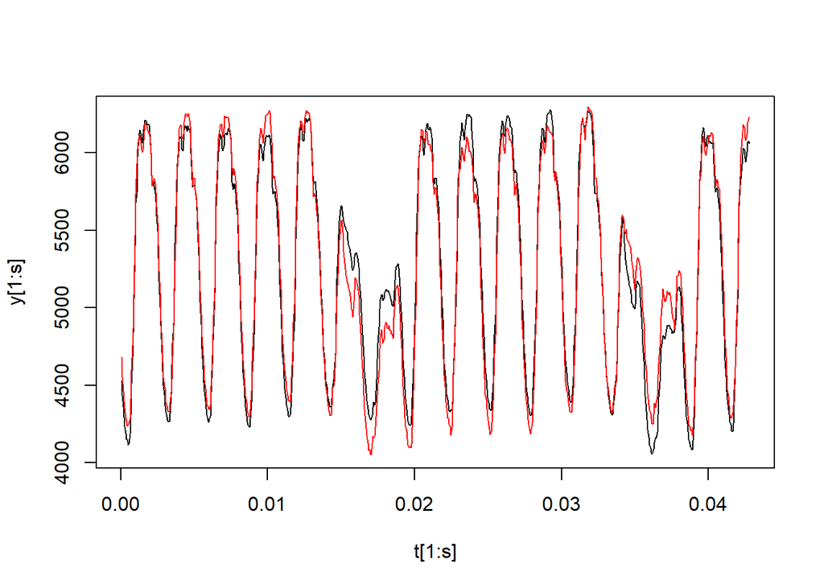

```r
freq = 1/(2*24*365.25)
t = seq(freq, length(y)*freq,by=freq)
s=750
plot(t[1:s],y[1:s],type='l')
ypred <- X%*%lmmodel$coefficients
lines(t[1:s],ypred[1:s],col='red')
```

When you set lag = 336, it predicts the data better. In the other graph, it shows what happens when you set lag = 300. Since we are using as predictors their lagged values, the longer the lag, the more data is being used to model the data. In the scenario with lag=300, we can see that the model trails the forecast as there is less of a lag used.

3. How can you compute the forecast one-week ahead using the below model?

```r
data <- read.csv("D:\\Trintiy\\Junior Sophister\\Semester 1\\Forecasting\\Assignment\\half-hourly-system-demand-data-from-2-feb-2012-onwards-2016-06-14T05-29-36Z.csv")
y = data$system_demand_actual
lag=336
X = do.call("rbind", lapply(list(y), function(x) embed(x, lag+1)))
Y = X[,1]; X = X[,-1]
lmmodel = lm(Y~X-1)
```

```r
forcast <- head(predict(lmmodel), n=(2*24*7))
forcast
```

```
##        1        2        3        4        5        6        7        8
## 4680.209 4554.781 4463.120 4395.700 4354.166 4290.516 4269.175 4238.444
##        9       10       11       12       13       14       15       16
## 4244.616 4258.263 4287.656 4411.989 4596.340 4757.020 4867.540 5083.078
##       17       18       19       20       21       22       23       24
## 5467.073 5732.653 5931.119 6022.543 6066.850 6112.282 6107.306 6082.945
##       25       26       27       28       29       30       31       32
## 6022.395 6004.643 6021.798 6137.825 6185.294 6182.515 6176.301 6156.610
##       33       34       35       36       37       38       39       40
## 6127.184 6137.187 6105.840 5995.490 5856.633 5786.504 5820.228 5834.919
##       41       42       43       44       45       46       47       48
## 5797.550 5742.914 5653.753 5550.475 5403.371 5237.292 5094.034 4919.953
##       49       50       51       52       53       54       55       56
## 4764.287 4650.673 4550.181 4490.142 4478.358 4394.370 4370.678 4343.098
##       57       58       59       60       61       62       63       64
## 4329.367 4331.703 4386.896 4455.296 4536.931 4688.567 4886.023 5125.213
##       65       66       67       68       69       70       71       72
## 5301.916 5522.424 5742.139 5911.278 6066.118 6156.440 6179.864 6177.275
##       73       74       75       76       77       78       79       80
## 6103.555 6091.601 6119.410 6200.101 6247.583 6252.095 6235.269 6240.346
##       81       82       83       84       85       86       87       88
## 6253.458 6208.866 6171.144 6033.662 5879.273 5790.287 5834.605 5839.360
##       89       90       91       92       93       94       95       96
## 5760.619 5708.318 5655.033 5557.663 5396.482 5241.375 5107.740 4958.164
##       97       98       99      100      101      102      103      104
## 4813.503 4698.642 4628.106 4535.771 4477.622 4425.315 4375.035 4364.056
##      105      106      107      108      109      110      111      112
## 4347.546 4347.057 4373.843 4495.985 4691.327 4829.472 4953.108 5127.454
##      113      114      115      116      117      118      119      120
## 5430.848 5717.761 5887.239 6008.453 6097.020 6147.871 6178.189 6186.771
##      121      122      123      124      125      126      127      128
## 6133.838 6101.143 6153.922 6236.293 6226.052 6232.303 6224.087 6224.119
##      129      130      131      132      133      134      135      136
## 6200.082 6135.809 6091.026 6004.773 5907.620 5856.646 5897.924 5883.736
##      137      138      139      140      141      142      143      144
## 5824.109 5747.398 5645.339 5538.956 5373.351 5210.516 5047.564 4915.811
##      145      146      147      148      149      150      151      152
## 4773.986 4661.178 4544.938 4491.150 4432.483 4390.355 4336.235 4324.278
##      153      154      155      156      157      158      159      160
## 4294.582 4307.100 4345.112 4463.453 4658.270 4840.377 4918.025 5067.443
```

[output cut: 29 more lines]

```
## 5104.587 5077.336 4994.727 4982.367 4940.163 5040.666 5116.626 5195.429
##      281      282      283      284      285      286      287      288
## 5177.118 5160.150 5140.252 5083.264 4954.662 4840.911 4762.952 4671.126
##      289      290      291      292      293      294      295      296
## 4544.776 4435.370 4346.043 4267.558 4222.423 4174.935 4129.324 4082.131
##      297      298      299      300      301      302      303      304
## 4084.324 4056.380 4054.593 4128.900 4171.008 4159.633 4176.015 4230.799
##      305      306      307      308      309      310      311      312
## 4369.330 4434.878 4510.895 4592.271 4734.614 4816.666 4857.067 4807.341
##      313      314      315      316      317      318      319      320
## 4771.822 4795.566 4878.955 4905.078 4901.198 4872.234 4867.448 4886.005
##      321      322      323      324      325      326      327      328
## 4859.663 4853.583 4829.577 4834.757 4805.207 4936.723 5039.886 5122.259
##      329      330      331      332      333      334      335      336
## 5121.791 5146.154 5131.710 5079.137 4965.300 4855.733 4739.336 4603.319
```